# pa1

- Task 1
  - Q1
- Task 2
  - Q2
  - Q3
  - Q4
- Task 3
  - Q5
  - Q6
  - Q7
  - Q8
  - Q9
  - Q10
- Task 4
  - Q11
  - Q12
  - Q13
  - Q14

## Task 1: Calculating the Win Rate

```python
import pandas as pd
import numpy as np
```

```python
pokemons = pd.read_csv('./data/pokemon.csv', sep=',')
battles = pd.read_csv('./data/battles.csv', sep=',')

pokemons = pd.DataFrame(pokemons)
battles = pd.DataFrame(battles)
```

```python
pokemons
```

|  | # | Name | Type 1 | Type 2 | HP | Attack | Defense | Sp. Atk | Sp. Def | Speed | Generation | Has Gender | Legendary |
| --- | --- | --- | --- | --- | --- | --- | --- | --- | --- | --- | --- | --- | --- |
| 0 | 1 | Bulbasaur | Grass | Poison | 45 | 49 | 49 | 65 | 65 | 45 | 1 | True | False |
| 1 | 2 | Ivysaur | Grass | Poison | 60 | 62 | 63 | 80 | 80 | 60 | 1 | True | False |
| 2 | 3 | Venusaur | Grass | Poison | 80 | 82 | 83 | 100 | 100 | 80 | 1 | True | False |
| 3 | 4 | Mega Venusaur | Grass | Poison | 80 | 100 | 123 | 122 | 120 | 80 | 1 | True | False |
| 4 | 5 | Charmander | Fire | NaN | 39 | 52 | 43 | 60 | 50 | 65 | 1 | True | False |
| ... | ... | ... | ... | ... | ... | ... | ... | ... | ... | ... | ... | ... | ... |
| 795 | 796 | Diancie | Rock | Fairy | 50 | 100 | 150 | 100 | 150 | 50 | 6 | False | True |
| 796 | 797 | Mega Diancie | Rock | Fairy | 50 | 160 | 110 | 160 | 110 | 110 | 6 | False | True |
| 797 | 798 | Hoopa Confined | Psychic | Ghost | 80 | 110 | 60 | 150 | 130 | 70 | 6 | False | True |
| 798 | 799 | Hoopa Unbound | Psychic | Dark | 80 | 160 | 60 | 170 | 130 | 80 | 6 | False | True |
| 799 | 800 | Volcanion | Fire | Water | 80 | 110 | 120 | 130 | 90 | 70 | 6 | False | True |

800 rows × 13 columns

```python
battles
```

|  | First_pokemon | Second_pokemon | Winner |
| --- | --- | --- | --- |
| 0 | 173 | 463 | 463 |
| 1 | 174 | 307 | 307 |
| 2 | 772 | 181 | 772 |
| 3 | 430 | 356 | 430 |
| 4 | 519 | 695 | 519 |
| ... | ... | ... | ... |
| 39995 | 416 | 778 | 778 |
| 39996 | 221 | 265 | 265 |
| 39997 | 35 | 448 | 448 |
| 39998 | 791 | 713 | 713 |
| 39999 | 312 | 486 | 486 |

40000 rows × 3 columns

```python
winRate = []
first_pokemon = battles['First_pokemon']
second_pokemon = battles['Second_pokemon']
winner = battles['Winner']

for index, row in pokemons.iterrows():
    wins = np.sum(winner == row['#'])
    total = np.sum(first_pokemon == row['#']) + np.sum(second_pokemon == row['#'])
    winRate.append(0 if total == 0 else wins / total) # 0% win rate if no battle record

# This is the result for [Q1]
pokemons['WinRate'] = winRate
pokemons.head()
```

|  | # | Name | Type 1 | Type 2 | HP | Attack | Defense | Sp. Atk | Sp. Def | Speed | Generation | Has Gender | Legendary | WinRate |
| --- | --- | --- | --- | --- | --- | --- | --- | --- | --- | --- | --- | --- | --- | --- |
| 0 | 1 | Bulbasaur | Grass | Poison | 45 | 49 | 49 | 65 | 65 | 45 | 1 | True | False | 0.254902 |
| 1 | 2 | Ivysaur | Grass | Poison | 60 | 62 | 63 | 80 | 80 | 60 | 1 | True | False | 0.395833 |
| 2 | 3 | Venusaur | Grass | Poison | 80 | 82 | 83 | 100 | 100 | 80 | 1 | True | False | 0.631068 |
| 3 | 4 | Mega Venusaur | Grass | Poison | 80 | 100 | 123 | 122 | 120 | 80 | 1 | True | False | 0.578947 |
| 4 | 5 | Charmander | Fire | NaN | 39 | 52 | 43 | 60 | 50 | 65 | 1 | True | False | 0.445652 |

### [Q1] When calculating the win rates of the Pokemons, you may notice that some of them have not participated in any battle. Explain how you deal with them.

**Your Answer:** I simply treat their win rate as 0%.

## Task 2: Finding the Most Correlated Feature using Linear Regression

```python
import sklearn as sk
import numpy as np
import matplotlib.pyplot as plt
from sklearn.model_selection import train_test_split
from sklearn.linear_model import LinearRegression
from sklearn.metrics import r2_score
```

```
R2 socre of HP:  	0.093010
R2 socre of Attack:  	0.215038
R2 socre of Defense:  	-0.015525
R2 socre of Sp. Atk:  	0.204860
R2 socre of Sp. Def:  	-0.015475
R2 socre of Speed:  	0.805541
```

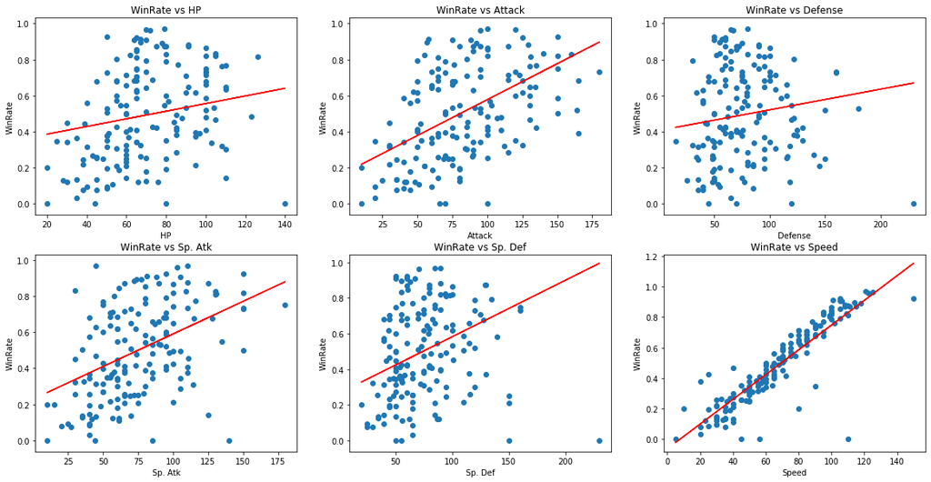

```python
train, val = train_test_split(pokemons, test_size=0.2, random_state=4211)

models = []
features = ['HP', 'Attack', 'Defense', 'Sp. Atk', 'Sp. Def', 'Speed']
plt.figure(figsize=(20, 10))

def reshape_feature(x):
    return x.values.reshape(-1, 1)

for idx, feature in enumerate(features):
    X_train = reshape_feature(train[feature])
    X_val = reshape_feature(val[feature])

    clf = LinearRegression()
    clf.fit(X_train, train['WinRate'])
    y_pred = clf.predict(X_val)
    # This is the result for [Q2]
    print('R2 socre of %s:  \t%f' % (feature, r2_score(val['WinRate'], y_pred)))

    # These are the result for [Q3]
    plt.subplot(2, 3, idx + 1)
    plt.scatter(X_val, reshape_feature(val['WinRate']))
    plt.plot(X_val, y_pred, color='red')
    plt.title('WinRate vs %s' % feature)
    plt.xlabel(feature)
    plt.ylabel('WinRate')

    models.append(clf)
```

### [Q2] Report the validation R2 score of each model to evaluate its prediction performance.

- R2 socre of HP: 0.093010
- R2 socre of Attack: 0.215038
- R2 socre of Defense: -0.015525
- R2 socre of Sp. Atk: 0.204860
- R2 socre of Sp. Def: -0.015475
- R2 socre of Speed: 0.805541

### [Q3] After training the models with the training set, use them to make prediction on the validation set. Then, plot the regression line and the data points of the validation set for each of the six models. For illustration, Figure 1 shows a plot of the win rate versus the feature ‘HP’ and the regression line.

[figure not shown]

### [Q4] By looking at the regression lines of the six plots, find the feature that is most correlated to the win rate. Explain how you find it.

The most correlated feature is Speed. According to the graph above, we can observe that Speed are positively proportional to WinRate, and the regression line perform same as the scatter points.

## Task 3: Legendary Pokemon Classification using Logistic Regression and Single-hidden-layer Neural Networks

```python
import sklearn as sk
import numpy as np
import matplotlib.pyplot as plt
from sklearn.model_selection import train_test_split
from sklearn.linear_model import SGDClassifier
from sklearn.metrics import f1_score, accuracy_score

import time
```

```python
# These are the variable and functions that will use in the whole Task 3 and Task 4

model_sample_size = 3 # train a model with same setting N times

def cat_to_ont_hot(dataSet, cat_vars=['Type 1', 'Type 2']):
    train = dataSet.copy()
    for var in cat_vars:
        cat_list='var'+'_'+var
        cat_list = pd.get_dummies(train[var], prefix=var)
        data=train.join(cat_list)
        train=data

    data_vars=train.columns.values.tolist()
    to_keep=[i for i in data_vars if i not in cat_vars]

    return train[to_keep]

def preprocess_data(data=pokemons):
    train, val = train_test_split(data, test_size=0.2, random_state=4211)

    train = cat_to_ont_hot(train)
    val = cat_to_ont_hot(val)

    val.insert(30, 'Type 2_Bug', np.zeros_like(val['Name']))
    val.insert(33, 'Type 2_Electric', np.zeros_like(val['Name']))

    return (train, val)

def report(models, size=model_sample_size, needGraph=False, xaxis=[1, 2, 4, 8, 16, 32, 64]):
    accuracies = []
    f1_scores = []
    for i in range(0, len(models), size):

        time_model, acc_model, f1_model = None, None, None
        best_time, best_acc, best_f1 = 0.0, 0.0, 0.0
        scope = np.arange(size)

        # arrays containing each statistics
        training_time = [models[i + j]['time'] for j in scope]
        accuracy = [(accuracy_score(y_val, models[i + j]['clf'].predict(X_val))) for j in scope]
        f1 =       [(      f1_score(y_val, models[i + j]['clf'].predict(X_val))) for j in scope]

        accuracies.append(np.mean(accuracy))
        f1_scores.append(np.mean(f1))

        if np.mean(training_time) > best_time:
            best_time = np.mean(training_time)
            time_model = models[i]
        if np.mean(accuracy) > best_acc:
            best_acc = np.mean(accuracy)
            acc_model = models[i]
        if np.mean(f1) > best_f1:
            best_f1 = np.mean(f1)
            f1_model = models[i]

        print('\n%d / %d' % (i, len(models)))
        print('Model Settings: ', models[i]['clf'])
        print('Mean Training Time: ', np.mean(training_time))
        print('SD of Training Time: ', np.std(training_time))
        print('Mean Accuracy: ', np.mean(accuracy))
        print('SD of Accuracy: ', np.std(accuracy))
        print('Mean F1 score: ', np.mean(f1))
        print('SD of F1 score: ', np.std(f1))

    if needGraph:
        plt.plot(xaxis, accuracies, label='accuracy')
        plt.plot(xaxis, f1_scores, label='f1 score')
        plt.xlabel('Hidden Units')
        plt.ylabel('Score')
        plt.legend()
        plt.savefig('tmp.png')

    print('\nBest Training Time; ', best_time)
    print(time_model)

    print('\nBest accuracy: ', best_acc)
    print(acc_model)

    print('\nBest f1 score: ', best_f1)
    print(f1_model)
```

```python
# data pre-processing
train, val = preprocess_data()

X_train = train.drop(['#', 'Name', 'Legendary', 'WinRate'], axis=1)
y_train = train.Legendary

X_val = val.drop(['#', 'Name', 'Legendary', 'WinRate'], axis=1)
y_val = val.Legendary

# hyperparameters combinations
learning_rates = [1e-4, 1e-3, 1e-2, 1e-1]
learning_schedules = ['constant', 'optimal', 'invscaling', 'adaptive']
iterations = [50, 100, 200, 500]

models = []

for it in iterations:
    for lr in learning_rates:
        for ls in learning_schedules:
            for i in np.arange(model_sample_size): # train N times for every settings
                model = {}
                clf = SGDClassifier(loss='log', alpha=lr, learning_rate=ls, eta0=lr, max_iter=it, random_state=0, verbose=1)
                start_time = time.time()
                clf.fit(X_train, y_train)
                model['time'] = time.time() - start_time
                model['clf'] = clf
                models.append(model)
                print("--- training time %s seconds ---" % (model['time']))
```

### [Q5] Report the model setting, training time, and performance of the logistic regression model. Since the solution found may depend on the initial weight values, you are expected to repeat each setting multiple times (e.g., three times) for the same hyperparameter setting and report the mean and standard deviation of the training time, accuracy, and F1 score for each setting.

```python
report(models)
```

```
0 / 192
Model Settings:  SGDClassifier(alpha=0.0001, average=False, class_weight=None,
              early_stopping=False, epsilon=0.1, eta0=0.0001,
              fit_intercept=True, l1_ratio=0.15, learning_rate='constant',
              loss='log', max_iter=50, n_iter_no_change=5, n_jobs=None,
              penalty='l2', power_t=0.5, random_state=0, shuffle=True,
              tol=0.001, validation_fraction=0.1, verbose=1, warm_start=False)
Mean Training Time:  0.005799770355224609
SD of Training Time:  0.0008791092971214892
Mean Accuracy:  0.8937500000000002
SD of Accuracy:  1.1102230246251565e-16
Mean F1 score:  0.0
SD of F1 score:  0.0

3 / 192
Model Settings:  SGDClassifier(alpha=0.0001, average=False, class_weight=None,
              early_stopping=False, epsilon=0.1, eta0=0.0001,
              fit_intercept=True, l1_ratio=0.15, learning_rate='optimal',
              loss='log', max_iter=50, n_iter_no_change=5, n_jobs=None,
              penalty='l2', power_t=0.5, random_state=0, shuffle=True,
              tol=0.001, validation_fraction=0.1, verbose=1, warm_start=False)
Mean Training Time:  0.014877716700236002
SD of Training Time:  0.003542388568115109
Mean Accuracy:  0.525
SD of Accuracy:  0.0
Mean F1 score:  0.2692307692307692
SD of F1 score:  0.0

6 / 192
Model Settings:  SGDClassifier(alpha=0.0001, average=False, class_weight=None,
              early_stopping=False, epsilon=0.1, eta0=0.0001,
              fit_intercept=True, l1_ratio=0.15, learning_rate='invscaling',
              loss='log', max_iter=50, n_iter_no_change=5, n_jobs=None,
              penalty='l2', power_t=0.5, random_state=0, shuffle=True,
              tol=0.001, validation_fraction=0.1, verbose=1, warm_start=False)
Mean Training Time:  0.008827606836954752
SD of Training Time:  0.00017320988984958317
Mean Accuracy:  0.8937500000000002
SD of Accuracy:  1.1102230246251565e-16
Mean F1 score:  0.0
```

[output cut: 864 more lines]

```
Best accuracy:  0.9187499999999998
{'time': 0.029457807540893555, 'clf': SGDClassifier(alpha=0.1, average=False, class_weight=None, early_stopping=False,
              epsilon=0.1, eta0=0.1, fit_intercept=True, l1_ratio=0.15,
              learning_rate='adaptive', loss='log', max_iter=500,
              n_iter_no_change=5, n_jobs=None, penalty='l2', power_t=0.5,
              random_state=0, shuffle=True, tol=0.001, validation_fraction=0.1,
              verbose=1, warm_start=False)}

Best f1 score:  0.48
{'time': 0.029457807540893555, 'clf': SGDClassifier(alpha=0.1, average=False, class_weight=None, early_stopping=False,
              epsilon=0.1, eta0=0.1, fit_intercept=True, l1_ratio=0.15,
              learning_rate='adaptive', loss='log', max_iter=500,
              n_iter_no_change=5, n_jobs=None, penalty='l2', power_t=0.5,
              random_state=0, shuffle=True, tol=0.001, validation_fraction=0.1,
              verbose=1, warm_start=False)}
```

```python
from sklearn.neural_network import MLPClassifier

hidden = [1, 2, 4, 8, 16, 32, 64]
iteration = 500

train, val = preprocess_data()
X_train = train.drop(['#', 'Name', 'Legendary', 'WinRate'], axis=1)
y_train = train.Legendary
X_val = val.drop(['#', 'Name', 'Legendary', 'WinRate'], axis=1)
y_val = val.Legendary

models = []

for hu in hidden:
    for i in np.arange(3):
        model = {}
        mlp = MLPClassifier(hidden_layer_sizes=(hu, ), max_iter=iteration, solver='sgd', random_state=4211)
        start_time = time.time()
        mlp.fit(X_train, y_train)
        model['time'] = time.time() - start_time
        model['clf'] = mlp
        models.append(model)
```

### [Q6] Report the model setting, training time, and performance of the neural networks for each value of H. You are also expected to repeat each setting multiple times for the same hyperpa- rameter setting and report the mean and standard deviation of the training time, accuracy, and F1 score for each setting.

```
0 / 21
Model Settings:  MLPClassifier(activation='relu', alpha=0.0001, batch_size='auto', beta_1=0.9,
              beta_2=0.999, early_stopping=False, epsilon=1e-08,
              hidden_layer_sizes=(1,), learning_rate='constant',
              learning_rate_init=0.001, max_fun=15000, max_iter=500,
              momentum=0.9, n_iter_no_change=10, nesterovs_momentum=True,
              power_t=0.5, random_state=4211, shuffle=True, solver='sgd',
              tol=0.0001, validation_fraction=0.1, verbose=False,
              warm_start=False)
Mean Training Time:  0.039336840311686196
SD of Training Time:  0.024183868082406506
Mean Accuracy:  0.8937500000000002
SD of Accuracy:  1.1102230246251565e-16
Mean F1 score:  0.0
SD of F1 score:  0.0

3 / 21
Model Settings:  MLPClassifier(activation='relu', alpha=0.0001, batch_size='auto', beta_1=0.9,
              beta_2=0.999, early_stopping=False, epsilon=1e-08,
              hidden_layer_sizes=(2,), learning_rate='constant',
              learning_rate_init=0.001, max_fun=15000, max_iter=500,
              momentum=0.9, n_iter_no_change=10, nesterovs_momentum=True,
              power_t=0.5, random_state=4211, shuffle=True, solver='sgd',
              tol=0.0001, validation_fraction=0.1, verbose=False,
              warm_start=False)
Mean Training Time:  0.42017173767089844
SD of Training Time:  0.0487880960629335
Mean Accuracy:  0.8937500000000002
SD of Accuracy:  1.1102230246251565e-16
Mean F1 score:  0.0
SD of F1 score:  0.0

6 / 21
Model Settings:  MLPClassifier(activation='relu', alpha=0.0001, batch_size='auto', beta_1=0.9,
              beta_2=0.999, early_stopping=False, epsilon=1e-08,
              hidden_layer_sizes=(4,), learning_rate='constant',
              learning_rate_init=0.001, max_fun=15000, max_iter=500,
              momentum=0.9, n_iter_no_change=10, nesterovs_momentum=True,
              power_t=0.5, random_state=4211, shuffle=True, solver='sgd',
              tol=0.0001, validation_fraction=0.1, verbose=False,
```

[output cut: 86 more lines]

```
              learning_rate_init=0.001, max_fun=15000, max_iter=500,
              momentum=0.9, n_iter_no_change=10, nesterovs_momentum=True,
              power_t=0.5, random_state=4211, shuffle=True, solver='sgd',
              tol=0.0001, validation_fraction=0.1, verbose=False,
              warm_start=False)}

Best f1 score:  0.4615384615384615
{'time': 0.5157709121704102, 'clf': MLPClassifier(activation='relu', alpha=0.0001, batch_size='auto', beta_1=0.9,
              beta_2=0.999, early_stopping=False, epsilon=1e-08,
              hidden_layer_sizes=(64,), learning_rate='constant',
              learning_rate_init=0.001, max_fun=15000, max_iter=500,
              momentum=0.9, n_iter_no_change=10, nesterovs_momentum=True,
              power_t=0.5, random_state=4211, shuffle=True, solver='sgd',
              tol=0.0001, validation_fraction=0.1, verbose=False,
              warm_start=False)}
```

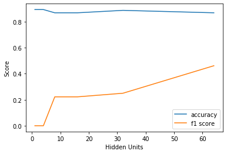

```python
report(models, needGraph=True, xaxis=hidden)
```

### [Q7] Compare the training time, accuracy and F1 score of the logistic regression model and the best neural network model.

```
SGDClassifier(alpha=0.1, average=False, class_weight=None, early_stopping=False,
          epsilon=0.1, eta0=0.1, fit_intercept=True, l1_ratio=0.15,
          learning_rate='adaptive', loss='log', max_iter=500,
          n_iter_no_change=5, n_jobs=None, penalty='l2', power_t=0.5,
          random_state=0, shuffle=True, tol=0.001, validation_fraction=0.1,
          verbose=1, warm_start=False)

Best Training Time;  0.04816102981567383
Best accuracy:  0.9187499999999998
Best f1 score:  0.48
```

#### Neural Network

```
MLPClassifier(activation='relu', alpha=0.0001, batch_size='auto', beta_1=0.9,
          beta_2=0.999, early_stopping=False, epsilon=1e-08,
          hidden_layer_sizes=(64,), learning_rate='constant',
          learning_rate_init=0.001, max_fun=15000, max_iter=500,
          momentum=0.9, n_iter_no_change=10, nesterovs_momentum=True,
          power_t=0.5, random_state=4211, shuffle=True, solver='sgd',
          tol=0.0001, validation_fraction=0.1, verbose=False,
          warm_start=False)

Best Training Time;  0.594632069269816
Best accuracy:  0.86875
Best f1 score:  0.4615384615384615
```

### [Q8] Plot the accuracy and the F1 score for different values of H.

[figure not shown]

### [Q9] Do you notice any trend when you increase the hidden layer size from 1 to 64? If so, please describe what the trend is.

With increasing the hidden layer size from 1 to 64, the f1 score increase while the accuracy score remain more or less the same.

### [Q10] Referring to your experiment results, comment on the gap between accuracy and the F1 score? Suggest a reason for this observation.

```python
pokemons['Legendary'].value_counts()
```

```
False    735
True      65
Name: Legendary, dtype: int64
```

## Task 4: Predicting the Winners in the Pokemon Battles

```python
import pandas as pd
from time import time
from sklearn.model_selection import GridSearchCV
from sklearn.utils.fixes import loguniform
```

```python
# Process the data, we will use all the features of the pokemon

def preprocess_data_task4(battles):
    pokemons = pd.read_csv('./data/pokemon.csv', sep=',')

    train = cat_to_ont_hot(pokemons)

    # link 'Second_pokemon' in battle to pokemon list
    first_result = pd.merge(train, battles, left_on='#', right_on='Second_pokemon')
    # Link 'First_pokemon' in battle to pokemon list
    result = pd.merge(train, first_result, left_on='#', right_on='First_pokemon', suffixes=('_First', '_Second'))
    # Change value of 'Winner' to 1 / 0, indicating the current pokemon win / loss
    result['Win'] = (result['Winner'] == result['#_First']) * 1
    # Drop all the unwanted features
    result = result.drop(['#_First', 'Name_First',
                          '#_Second', 'Name_Second',
                          'First_pokemon', 'Second_pokemon', 'Winner'], axis=1)

#     print(result.columns.values)
#     print()
#     print(result.head())
    return (result.iloc[:, :-1], result.iloc[:, -1:])

battles = pd.read_csv('./data/battles.csv', sep=',')
X_train, y_train = preprocess_data_task4(battles)

(X_train.shape, y_train.shape)
```

```
((40000, 90), (40000, 1))
```

```python
#*****************************************
#* DO NOT RUN THIS CELL AGAIN!!
#* LOAD THE MODEL FROM THE CELLS BELOW!!
#*****************************************

random_dist = {'hidden_layer_sizes': [(20, ), (10, 10), (15, 5), (50, 100, 50), (100, )],
               'solver': ['sgd', 'adam'],
               'learning_rate': ['constant', 'invscaling', 'adaptive'],
               'alpha': [0.0001, 0.05],
#                'learning_rate_init': loguniform(1e-4, 1e-1), #np.logspace(-4, -1, num=1000), #[1e-4, 1e-3, 1e-2],
               'activation': ['tanh', 'relu']}

# run grid search
mlp = MLPClassifier(max_iter=500)
grid_search = GridSearchCV(mlp, random_dist, n_jobs=-1, cv=5, verbose=3)
start = time()
grid_search.fit(X_train, y_train)
print("GridSearchCV took %.2f seconds for %d candidate parameter settings."
      % (time() - start, len(grid_search.cv_results_['params'])))
```

```
Fitting 5 folds for each of 120 candidates, totalling 600 fits
```

```
[Parallel(n_jobs=-1)]: Using backend LokyBackend with 4 concurrent workers.
[Parallel(n_jobs=-1)]: Done  24 tasks      | elapsed:  2.1min
[Parallel(n_jobs=-1)]: Done 120 tasks      | elapsed: 17.6min
[Parallel(n_jobs=-1)]: Done 280 tasks      | elapsed: 36.2min
[Parallel(n_jobs=-1)]: Done 504 tasks      | elapsed: 69.7min
[Parallel(n_jobs=-1)]: Done 600 out of 600 | elapsed: 86.2min finished
```

```
GridSearchCV took 5219.69 seconds for 120 candidate parameter settings.
```

```python
#*****************************************
#* DO NOT RUN THIS CELL AGAIN!!
#* LOAD THE MODEL FROM THE CELLS BELOW!!
#*****************************************

import pickle

filename = 'grid_search.sav'

# save model to disk
pickle.dump(grid_search, open(filename, 'wb'))
```

```python
import pickle

filename = 'task4_from_mac.sav'
# filename = 'task4_from_win.sav'

# load the model from disk
grid_search = pickle.load(open(filename, 'rb'))
```

### [Q11] Report 10 combinations of the hyperparameter setting.

```python
test = pd.read_csv('./data/q4_test.csv', sep=',')
X_test, y_test = preprocess_data_task4(test)

# print('Best parameters found:\n', grid_search.best_params_)

means = grid_search.cv_results_['mean_test_score']
stds = grid_search.cv_results_['std_test_score']
for mean, std, params in zip(means, stds, grid_search.cv_results_['params']):
    print('mean test score: %0.3f (std: %0.03f) for \n%r' % (mean, std * 2, params))
```

[output not shown]

[output cut: 187 more lines]

```
{'activation': 'relu', 'alpha': 0.05, 'hidden_layer_sizes': (50, 100, 50), 'learning_rate': 'adaptive', 'solver': 'sgd'}
mean test score: 0.935 (std: 0.018) for
{'activation': 'relu', 'alpha': 0.05, 'hidden_layer_sizes': (50, 100, 50), 'learning_rate': 'adaptive', 'solver': 'adam'}
mean test score: 0.939 (std: 0.007) for
{'activation': 'relu', 'alpha': 0.05, 'hidden_layer_sizes': (100,), 'learning_rate': 'constant', 'solver': 'sgd'}
mean test score: 0.938 (std: 0.012) for
{'activation': 'relu', 'alpha': 0.05, 'hidden_layer_sizes': (100,), 'learning_rate': 'constant', 'solver': 'adam'}
mean test score: 0.893 (std: 0.012) for
{'activation': 'relu', 'alpha': 0.05, 'hidden_layer_sizes': (100,), 'learning_rate': 'invscaling', 'solver': 'sgd'}
mean test score: 0.940 (std: 0.003) for
{'activation': 'relu', 'alpha': 0.05, 'hidden_layer_sizes': (100,), 'learning_rate': 'invscaling', 'solver': 'adam'}
mean test score: 0.945 (std: 0.009) for
{'activation': 'relu', 'alpha': 0.05, 'hidden_layer_sizes': (100,), 'learning_rate': 'adaptive', 'solver': 'sgd'}
mean test score: 0.934 (std: 0.021) for
{'activation': 'relu', 'alpha': 0.05, 'hidden_layer_sizes': (100,), 'learning_rate': 'adaptive', 'solver': 'adam'}
```

### [Q12] Report the three best hyperparameter settings as well as the mean and standard deviation of the validation accuracy of the five random data splits for each hyperparameter setting.

```python
result = pd.DataFrame(grid_search.cv_results_).sort_values(by='rank_test_score').head(3)
result.loc[:, ['mean_test_score', 'std_test_score', 'params']]
```

|  | mean_test_score | std_test_score | params |
| --- | --- | --- | --- |
| 52 | 0.948050 | 0.006249 | {'activation': 'tanh', 'alpha': 0.05, 'hidden_... |
| 67 | 0.947675 | 0.005045 | {'activation': 'relu', 'alpha': 0.0001, 'hidde... |
| 22 | 0.947600 | 0.006041 | {'activation': 'tanh', 'alpha': 0.0001, 'hidde... |

### [Q13] Use the best model to predict the instances in the test set (q4 test.csv). Report the accuracy.

```python
from sklearn.metrics import classification_report

y_pred = grid_search.predict(X_test)
print(classification_report(y_test, y_pred))
```

```
              precision    recall  f1-score   support

           0       0.97      0.94      0.95      5282
           1       0.94      0.97      0.95      4718

    accuracy                           0.95     10000
   macro avg       0.95      0.95      0.95     10000
weighted avg       0.95      0.95      0.95     10000
```

### [Q14] Print the confusion matrix of the predictions on the test set.

```
Confusion matrix:
[[4970  312]
 [ 165 4553]]
```

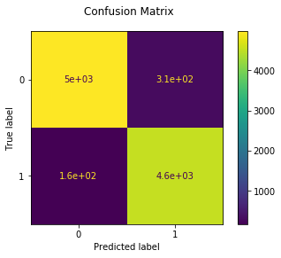

```python
from sklearn.metrics import plot_confusion_matrix

disp = plot_confusion_matrix(grid_search, X_test, y_test)
disp.figure_.suptitle("Confusion Matrix")
print("Confusion matrix:\n%s" % disp.confusion_matrix)
```